# Data Preparation

#### 2.2.8. Normalize `Brightness` column and add binary `Confidence Level` column

```r
normalit<-function(m){
   (m - min(m))/(max(m)-min(m))
}

avg <- mean(filtered_aus_fires$confidence)
std <- sd(filtered_aus_fires$confidence)

filtered_aus_fires <- filtered_aus_fires %>%
  filter(confidence <= (avg - std) | confidence >= (avg + std)) %>%
  mutate(confidence_level = cut(confidence, breaks=c('-inf', avg-std, 'inf'), labels=c(0,1)),
         brightness=normalit(brightness))

filtered_isr_fires <- isr_fires %>%
  filter(daynight == "D")%>%
  mutate(confidence_level = cut(confidence, breaks=c('-inf', avg-std, 'inf'), labels=c(0,1)),
          brightness = normalit(brightness))
```

#### 2.2.9. Maximum and Minimum temperatures in Australia by year

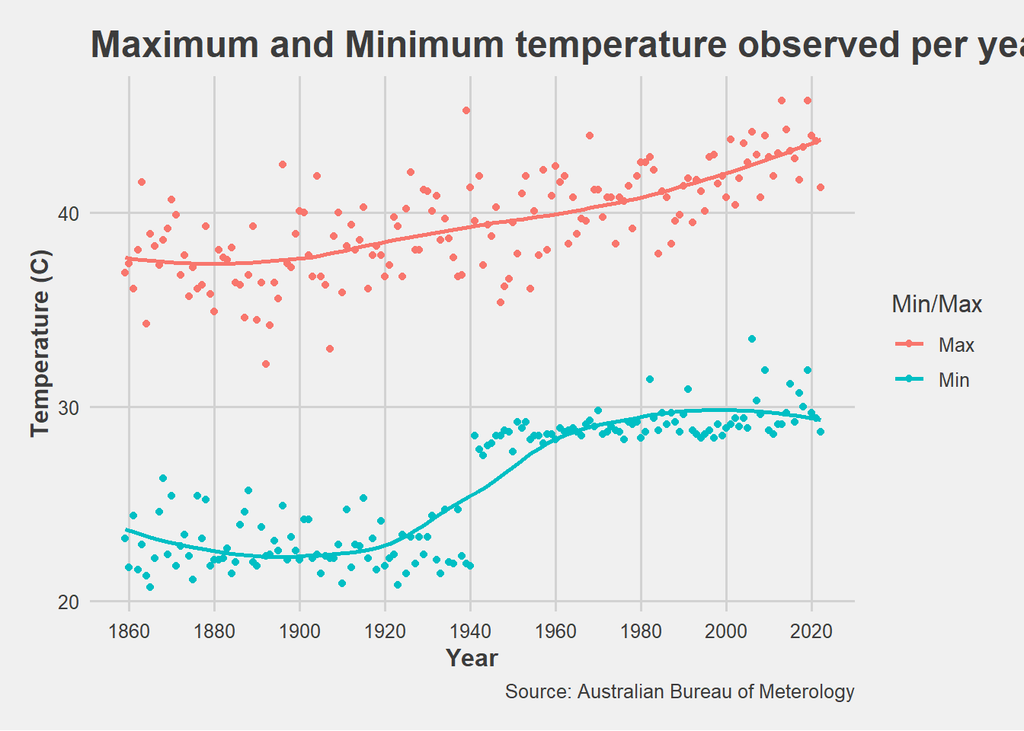

#### 2.2.10. Accumulated Rainfall in Israel by year

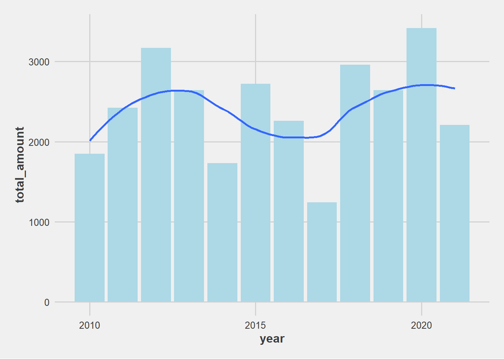

## 3. Join Spatial Data

Find the closest weather station and the distance for each fire record and insert as new columns

#### 2.1. Create function that returns a Distance Matrix between each fire location and each weather station

```r
myEuclid <- function(points1, points2) {
    distanceMatrix <- matrix(NA, nrow=dim(points1)[1], ncol=dim(points2)[1])
    for(i in 1:nrow(points2)) {
        for (j in c(1:dim(t(points1))[2])) {

        distanceMatrix[j,i] <- sqrt(rowSums(t(t(points1)[,j]-t(points2[i,]))^2))
            }
    }
    distanceMatrix
}
```

#### 2.2. Calculate the distance of each fire in Australia to the nearest rain station

```r
# aus_rain_stations <- aus_rainfall[!duplicated(aus_rainfall$station_name),] %>% select(station_name ,long, lat)
# aus_dist_rain <- myEuclid(filtered_aus_fires %>% select(longitude, latitude), aus_rain_stations %>% select(long, lat))
# aus_dist_rain <- as.data.frame(aus_dist_rain)
# aus_dist_rain$min_index <- apply(aus_dist_rain, 1, which.min)
# aus_dist_rain <- aus_dist_rain %>% rowwise() %>% mutate(min_value = min(V1, V2, V3, V4, V5, V6, V7),
#                                                         closest_station = case_when(
#                                                           min_index == 1 ~ "Darwin Botanic Gardens",
#                                                           min_index == 2 ~ "North Adelade",
#                                                           min_index == 3 ~ "Melbourne Botanical Gardens",
#                                                           min_index == 4 ~ "Subiaco Treatment Plant",
#                                                           min_index == 5 ~ "Brisbane Botanic Gardens",
#                                                           min_index == 6 ~ "Canberra Airport",
#                                                           min_index == 7 ~ "Sydney Observatory Hill"))
aus_dist_rain <- read.csv("./data/raw-data/aus_rainfall_dist_matrix.csv")
filtered_aus_fires$closest_rain_station <- aus_dist_rain$closest_station
filtered_aus_fires$distance_from_rain_station <- aus_dist_rain$min_value
```

#### 2.3. Calculate the distance of each fire in Australia to the nearest temperature station

```r
# aus_temp_stations <- aus_temperature[!duplicated(aus_temperature$station_name),] %>% select(station_name ,long, lat)
# aus_dist_temp <- myEuclid(filtered_aus_fires %>% select(longitude, latitude), aus_temp_stations %>% select(long, lat))
# aus_dist_temp <- as.data.frame(aus_dist_temp)
# aus_dist_temp$min_index <- apply(aus_dist_temp, 1, which.min)
# aus_dist_temp <- aus_dist_temp %>% rowwise() %>% mutate(min_value = min(V1, V2, V3, V4, V5, V6, V7),
#                                                         closest_station = case_when(
#                                                           min_index == 1 ~ "Sydney Observatory Hill",
#                                                           min_index == 2 ~ "Darwin Airport",
#                                                           min_index == 3 ~ "Adelaide Airport",
#                                                           min_index == 4 ~ "Swanbourne",
#                                                           min_index == 5 ~ "Brisbane",
#                                                           min_index == 6 ~ "Canberra Airport",
#                                                           min_index == 7 ~ "Melbourne Olympic Park"))
aus_dist_temp <- read.csv("./data/raw-data/aus_temp_dist_matrix.csv")
filtered_aus_fires$closest_temp_station <- aus_dist_temp$closest_station
filtered_aus_fires$distance_from_temp_station <- aus_dist_temp$min_value
```

#### 2.4. Calculate the distance of each fire in Israel to the nearest rain station

```r
isr_rain_stations <- isr_rainfall[!duplicated(isr_rainfall$station_name),] %>% select(station_name ,long, lat)
isr_dist_rain <- myEuclid(filtered_isr_fires %>% select(longitude, latitude), isr_rain_stations %>% select(long, lat))
isr_dist_rain <- as.data.frame(isr_dist_rain)
isr_dist_rain$min_index <- apply(isr_dist_rain, 1, which.min)
isr_dist_rain <- isr_dist_rain %>% rowwise() %>% mutate(min_value = min(V1, V2, V3, V4, V5, V6),
                                                        closest_station = case_when(
                                                          min_index == 1 ~ "Kfar Blum",
                                                          min_index == 2 ~ "Haifa-Technion",
                                                          min_index == 3 ~ "Beit Dagan",
                                                          min_index == 4 ~ "Beer Sheva",
                                                          min_index == 5 ~ "Eilat",
                                                          min_index == 6 ~ "Jerusalem Center"))
filtered_isr_fires$closest_rain_station <- isr_dist_rain$closest_station
filtered_isr_fires$distance_from_rain_station <- isr_dist_rain$min_value
```

#### 2.5. Calculate the distance of each fire in Israel to the nearest temperature station

```r
isr_temp_stations <- isr_temperature[!duplicated(isr_temperature$station_name),] %>% select(station_name ,long, lat)
isr_dist_temp <- myEuclid(filtered_isr_fires %>% select(longitude, latitude), isr_temp_stations %>% select(long, lat))
isr_dist_temp <- as.data.frame(isr_dist_temp)
isr_dist_temp$min_index <- apply(isr_dist_temp, 1, which.min)
isr_dist_temp <- isr_dist_temp %>% rowwise() %>% mutate(min_value = min(V1, V2, V3, V4, V5, V6, V7, V8),
                                                        closest_station = case_when(
                                                          min_index == 1 ~ "Beer Sheva",
                                                          min_index == 2 ~ "Eilat",
                                                          min_index == 3 ~ "Haifa-Technion",
                                                          min_index == 4 ~ "Jerusalem Center",
                                                          min_index == 5 ~ "Kfar Blum",
                                                          min_index == 6 ~ "Tel Aviv Beach",
                                                          min_index == 7 ~ "The Negev Junction",
                                                          min_index == 8 ~ "Beit Dagan"))
filtered_isr_fires$closest_temp_station <- isr_dist_temp$closest_station
filtered_isr_fires$distance_from_temp_station <- isr_dist_temp$min_value
```

#### 2.6. Add Temperature and Rainfall (7-day rolling sum) columns to each fire, measured by the closest weather station.

Since we have records of fires starting at 2010, we will filter the rainfall and temperature data to match that (Australia only).

```r
aus_rainfall_2010 <- aus_rainfall %>% filter(date >= "2010-01-01")
aus_temp_2010 <- aus_temperature %>% filter(date >= "2010-01-01", min.max == "max") %>%
                                select(date, station_name, temperature)
```

#### 2.7. Calculate the 7-day rolling sum of rainfall in Australia and join with the fire data

```r
aus_rainfall_2010 <- aus_rainfall_2010 %>%
                      replace(is.na(.), 0) %>%
                      arrange(date, station_name) %>%
                      group_by(station_name) %>%
                      mutate(rainfall_7d_sum = zoo::rollsum(amount, k = 7, fill=0)) %>%
                      ungroup() %>%
                      select(date, station_name, rainfall_7d_sum)
filtered_aus_fires <- filtered_aus_fires %>% left_join(aus_rainfall_2010, by=c("closest_rain_station" = "station_name", "acq_date"="date"))
```

#### 2.8. Add a temperature column to each fire in Australia, measured by the closest temperature station

```r
filtered_aus_fires <- filtered_aus_fires %>% left_join(aus_temp_2010, by=c("closest_temp_station" = "station_name", "acq_date"="date")) %>% replace(is.na(.), 0)
```

#### 2.9. Calculate the 7-day rolling sum of rainfall in Israel and join with the fire data

```r
isr_rainfall_join <- isr_rainfall %>%
                      drop_na() %>%
                      arrange(date, station_name) %>%
                      group_by(station_name) %>%
                      mutate(rainfall_7d_sum = zoo::rollsum(daily_amount, k = 7, fill=0)) %>%
                      ungroup() %>%
                      select(date, station_name, rainfall_7d_sum)
filtered_isr_fires <- filtered_isr_fires %>% left_join(isr_rainfall_join, by=c("closest_rain_station" = "station_name", "acq_date"="date"))
```

#### 2.10. Add a temperature column to each fire in Israel, measured by the closest temperature station

```r
isr_temp_join <- rename(isr_temperature,temperature = max_temp)
isr_temp_join <- isr_temp_join %>% mutate_at("temperature", as.numeric) %>% drop_na(temperature) %>% select(date, station_name, temperature)
filtered_isr_fires <- filtered_isr_fires %>% left_join(isr_temp_join, by=c("closest_temp_station" = "station_name", "acq_date"="date")) %>% mutate(rainfall_7d_sum = replace_na(rainfall_7d_sum, 0)) %>% drop_na(temperature)
```

## 3. Export the Transformed Data to .csv Files

Later to be used by the models

```r
write.csv(filtered_aus_fires, "./data/brightness-frp-model/filtered_aus_fires.csv")
write.csv(filtered_isr_fires, "./data/brightness-frp-model/filtered_isr_fires.csv")
```